# Pose accuracy and physical validity of three docking scoring functions

The full analysis report, read from the tables in results/

**show the code that produced this**

```python
import sys
from pathlib import Path

import os

import pandas as pd

# The report reads only files in results/ and figures/. It recomputes nothing, so
# a number here and the same number in the README come from one file.
#
# project.conf is located by walking up from the working directory rather than
# taken as a quarto parameter. Quarto renders from the qmd's own directory in
# some versions and from the project root in others, and a report that cannot
# find its own config depending on how it was invoked is not reproducible.
# VGB_CONFIG overrides, for the case where the config lives somewhere else.
candidates = []
if os.environ.get("VGB_CONFIG"):
    candidates.append(Path(os.environ["VGB_CONFIG"]))
here = Path.cwd().resolve()
candidates += [here / "project.conf"] + [p / "project.conf" for p in here.parents]
conf_file = next((c for c in candidates if c.is_file()), None)
if conf_file is None:
    raise SystemExit("project.conf not found; run scripts/00_configure.sh first")

sys.path.insert(0, str((conf_file.parent / "scripts").resolve()))
import lib_vgb as L

conf = L.load_conf(conf_file)
RESULTS = Path(conf["RESULTS_DIR"])
FIGURES = Path(conf["FIGURES_DIR"])
LOGS = Path(conf["LOG_DIR"])
PASS_A = L.conf_float(conf, "RMSD_PASS", 2.0)
STRICT_A = L.conf_float(conf, "RMSD_STRICT", 1.0)


def load(rel, root=RESULTS):
    p = Path(root) / rel
    if not p.is_file():
        return pd.DataFrame()
    return pd.read_csv(p, sep="\t")


success = load("success_rates.tsv")
arms = load("arm_comparison.tsv")
rmsd = load("rmsd_distributions.tsv")
timing = load("timing_distributions.tsv")
waterfall = load("pb_failure_waterfall.tsv")
symmetry = load("symmetry_effect.tsv")
seeds = load("seed_variance.tsv")
excluded = load("excluded.tsv")
versions = load("environment/versions.tsv")
provenance = load("data_provenance.tsv")
counts = load("dataset_counts.tsv")
xsummary = load("crossdock_set_summary.tsv")
prep_rec = load("preparation/receptor_prep.tsv")
prep_lig = load("preparation/ligand_prep.tsv")
align = load("preparation/crossdock_align.tsv")
boxes = pd.read_csv(Path(conf["CONFIG_DIR"]) / "boxes.tsv", sep="\t") \
    if (Path(conf["CONFIG_DIR"]) / "boxes.tsv").is_file() else pd.DataFrame()

print(f"report built from {RESULTS}")
print(f"tables loaded: success={len(success)} arms={len(arms)} runs_scored="
      f"{len(load('scored/run_scores.tsv'))}")
```

```
report built from /mnt/c/Users/User/Documents/Structural_Biology/vina_gnina_pose_benchmark_pipeline/results
tables loaded: success=23 arms=26 runs_scored=4400
```

## What was measured

Three docking scoring functions were run on two published benchmark sets and on a cross-docking set built here, under five protocols that differ only in how much crystallographic information the search was given. Every pose was scored twice: once for how far it sits from the crystal pose, using a symmetry-corrected root-mean-square deviation, and once for whether it is physically possible, using the PoseBusters checks. The number this report calls success requires both.

**show the code that produced this**

```python
if not success.empty:
    key = success[(success.dataset == "posebusters") &
                  (success.arm.isin(["A1_refconf_refbox", "A2_genconf_refbox",
                                     "A3_genconf_detbox"]))]
    show = key[["arm", "method", "n_scored", "n_assessed", "rmsd_le_2a_pct",
                "pb_valid_pct", "success_2a_pct", "rmsd_le_1a_pct",
                "top5_rmsd_le_2a_pct"]]
    display(show.sort_values(["arm", "method"]).reset_index(drop=True))
```

|  | arm | method | n_scored | n_assessed | rmsd_le_2a_pct | pb_valid_pct | success_2a_pct | rmsd_le_1a_pct | top5_rmsd_le_2a_pct |
| --- | --- | --- | --- | --- | --- | --- | --- | --- | --- |
| 0 | A1_refconf_refbox | gnina | 298 | 298 | 70.47 | 90.60 | 68.46 | 50.67 | 89.93 |
| 1 | A1_refconf_refbox | vina | 299 | 299 | 68.56 | 91.30 | 66.56 | 52.17 | 84.28 |
| 2 | A1_refconf_refbox | vinardo | 294 | 294 | 64.29 | 90.48 | 60.54 | 49.32 | 79.93 |
| 3 | A2_genconf_refbox | gnina | 298 | 298 | 58.39 | 87.25 | 55.70 | 36.58 | 81.21 |
| 4 | A2_genconf_refbox | vina | 299 | 299 | 55.52 | 87.29 | 53.51 | 36.45 | 71.91 |
| 5 | A2_genconf_refbox | vinardo | 294 | 294 | 50.68 | 89.46 | 48.30 | 35.03 | 68.37 |
| 6 | A3_genconf_detbox | gnina | 298 | 298 | 23.15 | 83.22 | 21.48 | 12.75 | 32.89 |
| 7 | A3_genconf_detbox | vina | 299 | 299 | 23.41 | 85.95 | 22.41 | 15.38 | 28.76 |
| 8 | A3_genconf_detbox | vinardo | 294 | 294 | 22.11 | 86.39 | 20.07 | 16.33 | 28.23 |

The columns are, in order: how many complexes produced a scorable pose, how many of those also got a validity verdict, the fraction of top-ranked poses within 2 Angstrom, the fraction passing every physical check, the fraction doing both, the same at 1 Angstrom, and the fraction where the best of the five kept poses is within 2 Angstrom.

## Data

**show the code that produced this**

```python
if not counts.empty:
    display(counts)
if not provenance.empty:
    display(provenance)
```

|  | dataset | in_archive | in_manifest | excluded_here | recorded |
| --- | --- | --- | --- | --- | --- |
| 0 | posebusters | 428 | 308 | 120 | 2026-09-22 |
| 1 | astex | 85 | 85 | 0 | 2026-09-22 |

|  | item | value |
| --- | --- | --- |
| 0 | zenodo_record | 8278563 |
| 1 | zenodo_publication_date | 2023-08-24 |
| 2 | zenodo_licence | cc-by-4.0 |
| 3 | archive_file | posebusters_paper_data.zip |
| 4 | archive_url | https://zenodo.org/api/records/8278563/files/p... |
| 5 | archive_bytes | 53660397 |
| 6 | archive_md5_upstream | f004ac7c4e68317b5348497d2bb6bee6 |
| 7 | archive_sha256_local | 495a8f432ee5612c0dfa3cc582829f112bfca3c29dddc2... |
| 8 | archive_downloaded | 2026-09-22T14:20:29+08:00 |
| 9 | posebusters_folders_in_archive | 428 |
| 10 | astex_folders_in_archive | 85 |
| 11 | ids_308_url | https://raw.githubusercontent.com/BioinfoMachi... |
| 12 | ids_308_commit | d2eeef8f2272d730d572ac22f3b25d48dc47966e |
| 13 | ids_308_sha256 | a69a7b6b9a5a52531933078ef983e6c069e3a987a1d7a7... |

The exclusions, by the stage that dropped each complex:

**show the code that produced this**

```python
if not excluded.empty:
    by_stage = (excluded.groupby(["stage"], as_index=False)
                .agg(n=("key", "size"))
                .sort_values("n", ascending=False))
    display(by_stage)
    print(f"total exclusion rows: {len(excluded)}")
    print("A complex can appear more than once: once per arm and method that "
          "failed on it, plus once for a preparation failure.")
```

|  | stage | n |
| --- | --- | --- |
| 0 | 02_fetch_benchmarks | 120 |
| 1 | 03_build_crossdock_set | 55 |
| 2 | 04_prepare/crossdock_align | 48 |
| 4 | 06_dock/A1_refconf_refbox/vina | 16 |
| 5 | 06_dock/A1_refconf_refbox/vinardo | 16 |
| 8 | 06_dock/A2_genconf_refbox/vinardo | 16 |
| 7 | 06_dock/A2_genconf_refbox/vina | 16 |
| 10 | 06_dock/A3_genconf_detbox/vina | 16 |
| 11 | 06_dock/A3_genconf_detbox/vinardo | 16 |
| 6 | 06_dock/A2_genconf_refbox/gnina | 12 |
| 3 | 06_dock/A1_refconf_refbox/gnina | 12 |
| 9 | 06_dock/A3_genconf_detbox/gnina | 12 |
| 13 | 06_dock/A4_crossdock/vina | 8 |
| 14 | 06_dock/A4_crossdock/vinardo | 8 |
| 12 | 06_dock/A4_crossdock/gnina | 6 |

```
total exclusion rows: 377
A complex can appear more than once: once per arm and method that failed on it, plus once for a preparation failure.
```

## The cross-docking set

**show the code that produced this**

```python
if not xsummary.empty:
    display(xsummary)
if not align.empty:
    ok = align[align.status == "ok"]
    print(f"pairs prepared: {len(ok)} of {len(align)}")
    if "ca_rmsd_after_superposition" in ok:
        q = ok.ca_rmsd_after_superposition.describe()
        print("C-alpha RMSD after superposing query onto receptor:")
        print(f"  median {ok.ca_rmsd_after_superposition.median():.2f} A, "
              f"max {ok.ca_rmsd_after_superposition.max():.2f} A over {len(ok)} pairs")
    if "sequence_identity_of_matched" in ok:
        print(f"  sequence identity of matched residues: median "
              f"{ok.sequence_identity_of_matched.median():.3f}")
```

|  | item | value |
| --- | --- | --- |
| 0 | queries_considered | 308 |
| 1 | pairs_built | 253 |
| 2 | queries_paired | 253 |
| 3 | queries_excluded | 55 |
| 4 | max_resolution_angstrom | 2.5 |
| 5 | min_sequence_identity_percent | 95 |
| 6 | max_partners_per_query | 1 |
| 7 | min_ligand_heavy_atoms | 10 |
| 8 | additives_excluded_count | 81 |
| 9 | rcsb_api_calls | 725 |
| 10 | built | 2026-09-22T14:47:02+08:00 |
| 11 | excluded_no_partner_below_identity_cutoff | 5 |
| 12 | excluded_no_partner_no_ligand_of_interest | 19 |
| 13 | excluded_no_partner_same_ligand_only | 7 |
| 14 | excluded_no_query_entry | 1 |
| 15 | excluded_no_same_protein_entry | 17 |
| 16 | excluded_no_uniprot | 6 |

```
pairs prepared: 205 of 253
C-alpha RMSD after superposing query onto receptor:
  median 0.54 A, max 2.96 A over 205 pairs
  sequence identity of matched residues: median 1.000
```

## Results

### What each piece of crystal information is worth

**show the code that produced this**

```python
from IPython.display import Image, display as d
p = FIGURES / "fig1_arm_ladder.png"
if p.is_file():
    d(Image(filename=str(p)))
if not arms.empty:
    display(arms[["from_arm", "to_arm", "method", "dataset", "from_success_2a_pct",
                  "to_success_2a_pct", "delta_pp", "meaning"]])
```

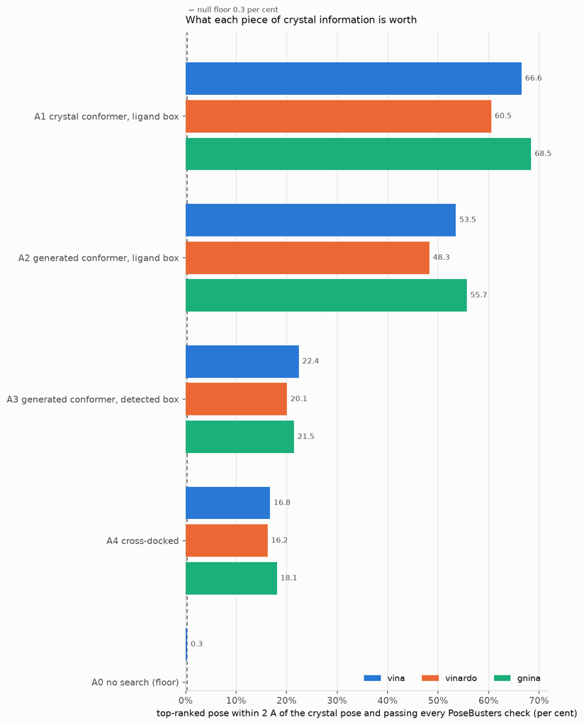

(a)

|  | from_arm | to_arm | method | dataset | from_success_2a_pct | to_success_2a_pct | delta_pp | meaning |
| --- | --- | --- | --- | --- | --- | --- | --- | --- |
| 0 | A1_refconf_refbox | A2_genconf_refbox | gnina | astex | 73.49 | 68.67 | -4.82 | cost of generating the starting conformer inst... |
| 1 | A1_refconf_refbox | A2_genconf_refbox | gnina | posebusters | 68.46 | 55.70 | -12.76 | cost of generating the starting conformer inst... |
| 2 | A1_refconf_refbox | A2_genconf_refbox | vina | astex | 75.64 | 52.56 | -23.08 | cost of generating the starting conformer inst... |
| 3 | A1_refconf_refbox | A2_genconf_refbox | vina | posebusters | 66.56 | 53.51 | -13.05 | cost of generating the starting conformer inst... |
| 4 | A1_refconf_refbox | A2_genconf_refbox | vinardo | astex | 68.67 | 57.83 | -10.84 | cost of generating the starting conformer inst... |
| 5 | A1_refconf_refbox | A2_genconf_refbox | vinardo | posebusters | 60.54 | 48.30 | -12.24 | cost of generating the starting conformer inst... |
| 6 | A2_genconf_refbox | A3_genconf_detbox | gnina | astex | 68.67 | 24.69 | -43.98 | cost of taking the box from pocket detection i... |
| 7 | A2_genconf_refbox | A3_genconf_detbox | gnina | posebusters | 55.70 | 21.48 | -34.22 | cost of taking the box from pocket detection i... |
| 8 | A2_genconf_refbox | A3_genconf_detbox | vina | astex | 52.56 | 21.05 | -31.51 | cost of taking the box from pocket detection i... |
| 9 | A2_genconf_refbox | A3_genconf_detbox | vina | posebusters | 53.51 | 22.41 | -31.10 | cost of taking the box from pocket detection i... |
| 10 | A2_genconf_refbox | A3_genconf_detbox | vinardo | astex | 57.83 | 16.05 | -41.78 | cost of taking the box from pocket detection i... |
| 11 | A2_genconf_refbox | A3_genconf_detbox | vinardo | posebusters | 48.30 | 20.07 | -28.23 | cost of taking the box from pocket detection i... |
| 12 | A1_refconf_refbox | A3_genconf_detbox | gnina | astex | 73.49 | 24.69 | -48.80 | cost of removing both, which is the gap betwee... |
| 13 | A1_refconf_refbox | A3_genconf_detbox | gnina | posebusters | 68.46 | 21.48 | -46.98 | cost of removing both, which is the gap betwee... |
| 14 | A1_refconf_refbox | A3_genconf_detbox | vina | astex | 75.64 | 21.05 | -54.59 | cost of removing both, which is the gap betwee... |
| 15 | A1_refconf_refbox | A3_genconf_detbox | vina | posebusters | 66.56 | 22.41 | -44.15 | cost of removing both, which is the gap betwee... |
| 16 | A1_refconf_refbox | A3_genconf_detbox | vinardo | astex | 68.67 | 16.05 | -52.62 | cost of removing both, which is the gap betwee... |
| 17 | A1_refconf_refbox | A3_genconf_detbox | vinardo | posebusters | 60.54 | 20.07 | -40.47 | cost of removing both, which is the gap betwee... |
| 18 | A2_genconf_refbox | A4_crossdock | gnina | astex | 68.67 | 18.09 | -50.58 | cost of docking into a structure solved with a... |
| 19 | A2_genconf_refbox | A4_crossdock | gnina | posebusters | 55.70 | 18.09 | -37.61 | cost of docking into a structure solved with a... |
| 20 | A2_genconf_refbox | A4_crossdock | vina | astex | 52.56 | 16.75 | -35.81 | cost of docking into a structure solved with a... |
| 21 | A2_genconf_refbox | A4_crossdock | vina | posebusters | 53.51 | 16.75 | -36.76 | cost of docking into a structure solved with a... |
| 22 | A2_genconf_refbox | A4_crossdock | vinardo | astex | 57.83 | 16.24 | -41.59 | cost of docking into a structure solved with a... |
| 23 | A2_genconf_refbox | A4_crossdock | vinardo | posebusters | 48.30 | 16.24 | -32.06 | cost of docking into a structure solved with a... |
| 24 | A0_null | A2_genconf_refbox | vina | astex | 0.00 | 52.56 | 52.56 | what the search buys over dropping the conform... |
| 25 | A0_null | A2_genconf_refbox | vina | posebusters | 0.32 | 53.51 | 53.19 | what the search buys over dropping the conform... |

(b)

Figure 1

### Accuracy against validity

**show the code that produced this**

```python
p = FIGURES / "fig2_rmsd_vs_validity.png"
if p.is_file():
    d(Image(filename=str(p)))
if not waterfall.empty:
    top = (waterfall.sort_values("pct_failed", ascending=False)
           .groupby("method").head(6)
           [["method", "arm", "check", "n_top1_assessed", "n_failed", "pct_failed"]])
    display(top.reset_index(drop=True))
```

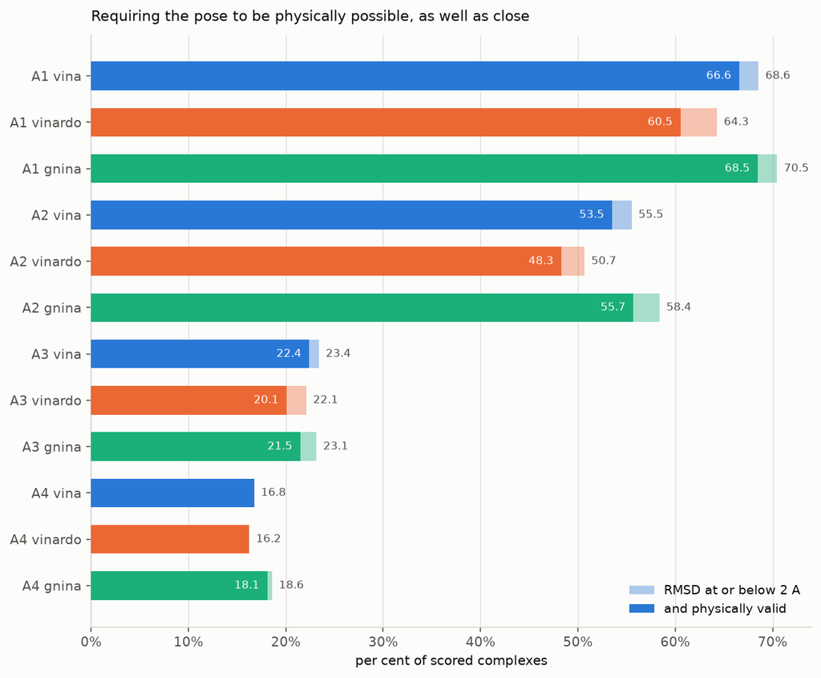

(a)

|  | method | arm | check | n_top1_assessed | n_failed | pct_failed |
| --- | --- | --- | --- | --- | --- | --- |
| 0 | vina | A0_null | pb_minimum_distance_to_protein | 85 | 84 | 98.82 |
| 1 | vina | A0_null | pb_minimum_distance_to_protein | 308 | 301 | 97.73 |
| 2 | vina | A0_null | pb_volume_overlap_with_protein | 85 | 80 | 94.12 |
| 3 | vina | A0_null | pb_volume_overlap_with_protein | 308 | 287 | 93.18 |
| 4 | vina | A0_null | pb_minimum_distance_to_organic_cofactors | 85 | 10 | 11.76 |
| 5 | vina | A0_null | pb_minimum_distance_to_organic_cofactors | 308 | 32 | 10.39 |
| 6 | gnina | A3_genconf_detbox | pb_minimum_distance_to_organic_cofactors | 298 | 29 | 9.73 |
| 7 | vinardo | A3_genconf_detbox | pb_minimum_distance_to_organic_cofactors | 294 | 23 | 7.82 |
| 8 | vinardo | A2_genconf_refbox | pb_minimum_distance_to_organic_cofactors | 294 | 19 | 6.46 |
| 9 | gnina | A3_genconf_detbox | pb_minimum_distance_to_protein | 298 | 19 | 6.38 |
| 10 | gnina | A3_genconf_detbox | pb_volume_overlap_with_organic_cofactors | 298 | 17 | 5.70 |
| 11 | vinardo | A3_genconf_detbox | pb_volume_overlap_with_organic_cofactors | 294 | 15 | 5.10 |
| 12 | gnina | A2_genconf_refbox | pb_minimum_distance_to_organic_cofactors | 298 | 15 | 5.03 |
| 13 | gnina | A1_refconf_refbox | pb_minimum_distance_to_organic_cofactors | 298 | 15 | 5.03 |
| 14 | vinardo | A3_genconf_detbox | pb_minimum_distance_to_inorganic_cofactors | 81 | 4 | 4.94 |
| 15 | vinardo | A1_refconf_refbox | pb_minimum_distance_to_organic_cofactors | 294 | 14 | 4.76 |
| 16 | vinardo | A3_genconf_detbox | pb_minimum_distance_to_inorganic_cofactors | 294 | 13 | 4.42 |
| 17 | gnina | A2_genconf_refbox | pb_minimum_distance_to_protein | 298 | 13 | 4.36 |

(b)

Figure 2

### Benchmark choice

**show the code that produced this**

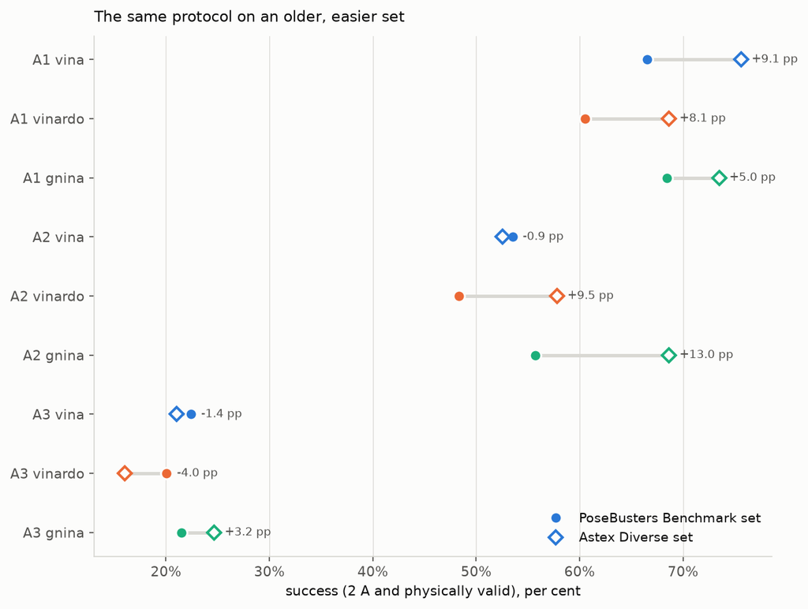

Figure 3

```python
p = FIGURES / "fig3_benchmark_gap.png"
if p.is_file():
    d(Image(filename=str(p)))
```

### The shape behind the fraction

**show the code that produced this**

```python
p = FIGURES / "fig4_rmsd_ecdf.png"
if p.is_file():
    d(Image(filename=str(p)))
if not rmsd.empty:
    display(rmsd[rmsd.quantity == "top1_rmsd"]
            [["arm", "method", "dataset", "n", "q25", "median", "q75", "q90", "max"]]
            .reset_index(drop=True))
```

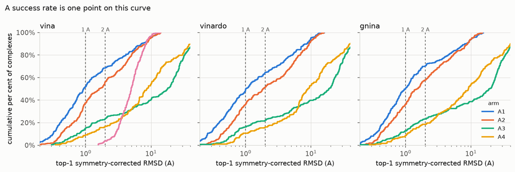

(a)

|  | arm | method | dataset | n | q25 | median | q75 | q90 | max |
| --- | --- | --- | --- | --- | --- | --- | --- | --- | --- |
| 0 | A0_null | vina | astex | 85.0 | 4.001 | 5.372 | 6.501 | 7.712 | 12.205 |
| 1 | A0_null | vina | posebusters | 308.0 | 3.562 | 4.958 | 6.668 | 8.279 | 13.928 |
| 2 | A1_refconf_refbox | gnina | astex | 83.0 | 0.431 | 0.718 | 1.794 | 4.030 | 12.127 |
| 3 | A1_refconf_refbox | gnina | posebusters | 298.0 | 0.527 | 0.997 | 3.076 | 8.224 | 15.572 |
| 4 | A1_refconf_refbox | vina | astex | 78.0 | 0.463 | 0.733 | 1.778 | 4.836 | 10.131 |
| 5 | A1_refconf_refbox | vina | posebusters | 299.0 | 0.491 | 0.932 | 2.884 | 7.122 | 13.873 |
| 6 | A1_refconf_refbox | vinardo | astex | 83.0 | 0.435 | 0.721 | 2.415 | 6.705 | 13.849 |
| 7 | A1_refconf_refbox | vinardo | posebusters | 294.0 | 0.477 | 1.017 | 3.913 | 8.387 | 15.930 |
| 8 | A2_genconf_refbox | gnina | astex | 83.0 | 0.667 | 1.316 | 2.432 | 6.755 | 13.659 |
| 9 | A2_genconf_refbox | gnina | posebusters | 298.0 | 0.707 | 1.440 | 4.097 | 8.564 | 14.926 |
| 10 | A2_genconf_refbox | vina | astex | 78.0 | 0.762 | 1.659 | 3.789 | 6.928 | 12.798 |
| 11 | A2_genconf_refbox | vina | posebusters | 299.0 | 0.814 | 1.717 | 4.384 | 8.460 | 14.087 |
| 12 | A2_genconf_refbox | vinardo | astex | 83.0 | 0.657 | 1.330 | 3.781 | 6.684 | 13.462 |
| 13 | A2_genconf_refbox | vinardo | posebusters | 294.0 | 0.740 | 1.955 | 5.757 | 9.382 | 15.871 |
| 14 | A3_genconf_detbox | gnina | astex | 81.0 | 2.321 | 19.762 | 29.966 | 48.437 | 96.929 |
| 15 | A3_genconf_detbox | gnina | posebusters | 298.0 | 2.309 | 19.096 | 29.398 | 44.651 | 90.846 |
| 16 | A3_genconf_detbox | vina | astex | 76.0 | 3.475 | 18.852 | 28.735 | 44.606 | 96.715 |
| 17 | A3_genconf_detbox | vina | posebusters | 299.0 | 2.140 | 17.826 | 30.041 | 44.001 | 89.529 |
| 18 | A3_genconf_detbox | vinardo | astex | 81.0 | 4.541 | 19.313 | 30.064 | 43.733 | 95.879 |
| 19 | A3_genconf_detbox | vinardo | posebusters | 294.0 | 2.970 | 18.744 | 30.677 | 44.447 | 90.557 |
| 20 | A4_crossdock | gnina | crossdock | 199.0 | 2.957 | 9.125 | 20.961 | 40.600 | 74.962 |
| 21 | A4_crossdock | vina | crossdock | 197.0 | 3.647 | 8.615 | 20.600 | 40.423 | 75.284 |
| 22 | A4_crossdock | vinardo | crossdock | 197.0 | 4.364 | 9.029 | 21.368 | 38.932 | 75.318 |

(b)

Figure 4

### Physical failures

**show the code that produced this**

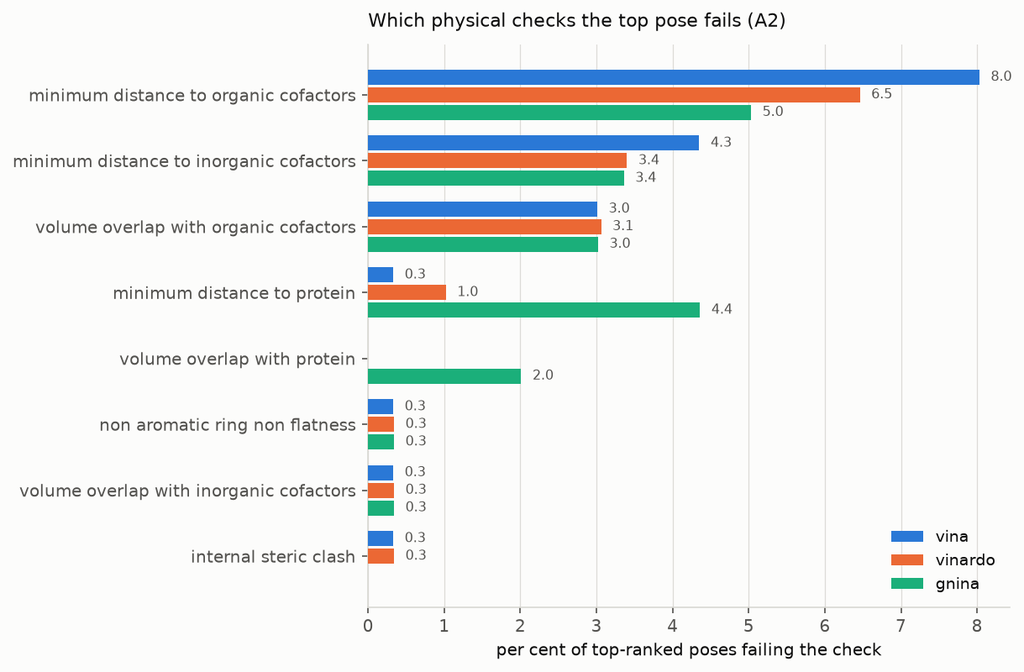

Figure 5

```python
p = FIGURES / "fig5_pb_failure_waterfall.png"
if p.is_file():
    d(Image(filename=str(p)))
```

### Search against ranking

**show the code that produced this**

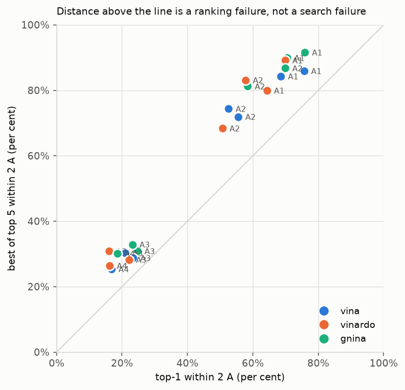

Figure 6

```python
p = FIGURES / "fig6_top1_vs_top5.png"
if p.is_file():
    d(Image(filename=str(p)))
```

A large gap between top-1 and top-5 means the search found the pose and the scoring function failed to rank it first. That is a different diagnosis from a small gap, and it has a different fix: rescoring the poses you already have, rather than searching harder.

### Cost

**show the code that produced this**

```python
p = FIGURES / "fig7_timing.png"
if p.is_file():
    d(Image(filename=str(p)))
if not timing.empty:
    display(timing[["arm", "method", "dataset", "jobs", "n", "median", "q90",
                    "max", "total_core_seconds"]].reset_index(drop=True))
```

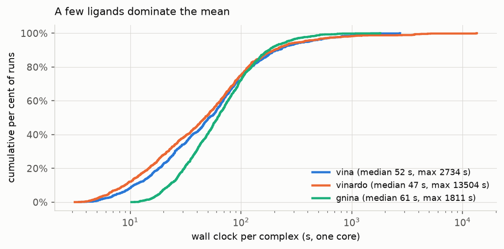

(a)

[output not shown]

(b)

Figure 7

### Run-to-run variance

**show the code that produced this**

```python
p = FIGURES / "fig8_seed_variance.png"
if p.is_file():
    d(Image(filename=str(p)))
if not seeds.empty:
    display(seeds[["method", "complex_id", "n_seeds", "rmsd_values", "range_rmsd",
                   "stdev_rmsd", "verdict_unanimous"]])
```

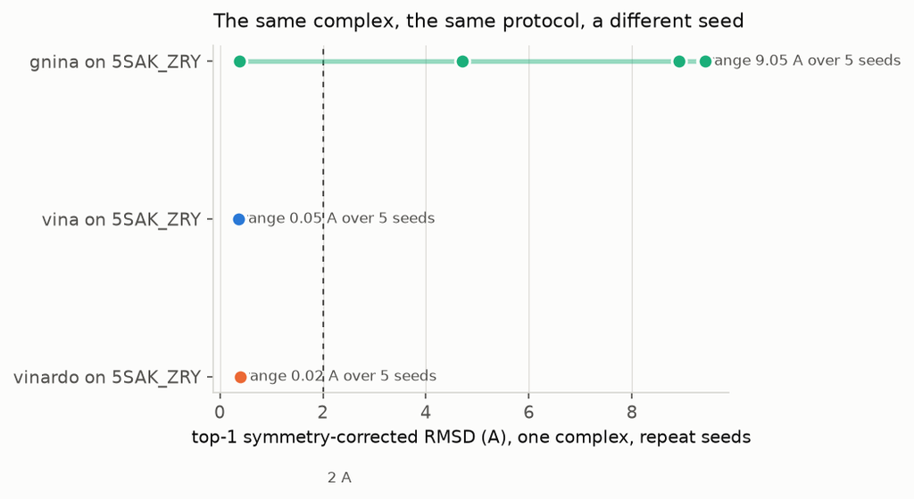

(a)

|  | method | complex_id | n_seeds | rmsd_values | range_rmsd | stdev_rmsd | verdict_unanimous |
| --- | --- | --- | --- | --- | --- | --- | --- |
| 0 | gnina | 5SAK_ZRY | 5 | 0.376,9.404,4.705,8.905,9.425 | 9.049 | 3.9837 | 0 |
| 1 | vina | 5SAK_ZRY | 5 | 0.332,0.368,0.354,0.382,0.356 | 0.051 | 0.0188 | 1 |
| 2 | vinardo | 5SAK_ZRY | 5 | 0.409,0.401,0.396,0.413,0.397 | 0.016 | 0.0073 | 1 |

(b)

Figure 8

### Whether pocket detection finds the site

**show the code that produced this**

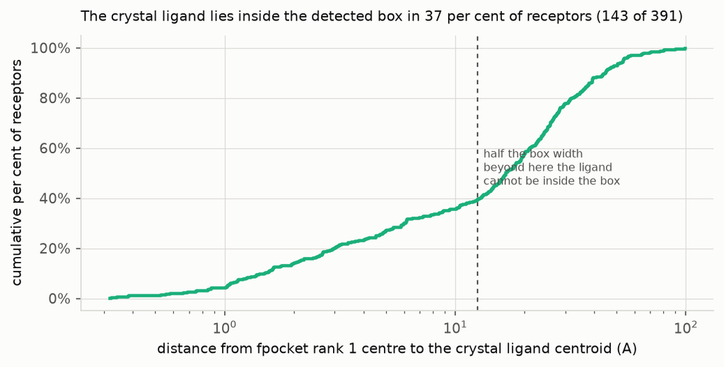

Figure 9

```
crystal ligand inside the detected box: 143 of 391 (36.6 per cent)
median distance from fpocket rank 1 centre to the crystal ligand centroid: 16.5 A
```

```python
p = FIGURES / "fig9_pocket_detection.png"
if p.is_file():
    d(Image(filename=str(p)))
if not boxes.empty:
    det = boxes[(boxes.arm_box_kind == "detected") & (boxes.status == "ok")]
    if not det.empty and "ligand_fits_in_box" in det:
        inside = (det.ligand_fits_in_box == 1).sum()
        print(f"crystal ligand inside the detected box: {inside} of {len(det)} "
              f"({100.0 * inside / len(det):.1f} per cent)")
        print(f"median distance from fpocket rank 1 centre to the crystal ligand "
              f"centroid: {det.distance_to_crystal_centroid.median():.1f} A")
```

### How much of this is sampling noise

Every number above was produced at the docking programs’ own default search effort, which is also the setting the protocol these results are compared against uses. That default does not converge on a 25 Angstrom box, and the size of the resulting noise is a property of the standard protocol rather than of this pipeline.

**show the code that produced this**

```python
conv = load("convergence.tsv")
if not conv.empty:
    display(conv[["method", "exhaustiveness", "n_runs", "n_complexes",
                  "rmsd_le_2a_pct", "median_rmsd", "median_elapsed_s",
                  "complexes_where_seeds_disagree", "pct_seeds_disagree",
                  "mean_seed_range_a", "max_seed_range_a"]])
else:
    print("results/convergence.tsv is empty. Run:")
    print("  bash scripts/06_dock.sh --convergence --method vina")
```

```
results/convergence.tsv is empty. Run:
  bash scripts/06_dock.sh --convergence --method vina
```

Two individual cases make the mechanism concrete, and they fail differently.

Both failures are invisible in the arm that starts from crystal coordinates, which is the arm the standard protocol reports.

### Symmetry correction

**show the code that produced this**

```python
if not symmetry.empty:
    display(symmetry[["arm", "method", "dataset", "n_with_both",
                      "n_verdict_changed", "pct_verdict_changed",
                      "median_abs_difference", "max_abs_difference",
                      "n_spyrmsd_disagrees_over_0p1a"]].reset_index(drop=True))
```

|  | arm | method | dataset | n_with_both | n_verdict_changed | pct_verdict_changed | median_abs_difference | max_abs_difference | n_spyrmsd_disagrees_over_0p1a |
| --- | --- | --- | --- | --- | --- | --- | --- | --- | --- |
| 0 | A0_null | vina | astex | 85 | 0 | 0.00 | 0.0089 | 3.9067 | 0 |
| 1 | A0_null | vina | posebusters | 308 | 3 | 0.97 | 0.0146 | 13.7052 | 0 |
| 2 | A1_refconf_refbox | gnina | astex | 83 | 2 | 2.41 | 0.0286 | 1.3453 | 0 |
| 3 | A1_refconf_refbox | gnina | posebusters | 298 | 6 | 2.01 | 0.0000 | 4.7999 | 0 |
| 4 | A1_refconf_refbox | vina | astex | 78 | 2 | 2.56 | 0.0000 | 2.1905 | 1 |
| 5 | A1_refconf_refbox | vina | posebusters | 299 | 5 | 1.67 | 0.0000 | 18.9668 | 1 |
| 6 | A1_refconf_refbox | vinardo | astex | 83 | 5 | 6.02 | 0.0000 | 3.0440 | 0 |
| 7 | A1_refconf_refbox | vinardo | posebusters | 294 | 11 | 3.74 | 0.0028 | 19.0141 | 1 |
| 8 | A2_genconf_refbox | gnina | astex | 83 | 3 | 3.61 | 0.0599 | 4.2202 | 0 |
| 9 | A2_genconf_refbox | gnina | posebusters | 298 | 9 | 3.02 | 0.0311 | 5.8284 | 2 |
| 10 | A2_genconf_refbox | vina | astex | 78 | 3 | 3.85 | 0.0229 | 6.4621 | 0 |
| 11 | A2_genconf_refbox | vina | posebusters | 299 | 14 | 4.68 | 0.0285 | 5.9947 | 2 |
| 12 | A2_genconf_refbox | vinardo | astex | 83 | 4 | 4.82 | 0.0297 | 4.2489 | 0 |
| 13 | A2_genconf_refbox | vinardo | posebusters | 294 | 11 | 3.74 | 0.0191 | 5.2587 | 1 |
| 14 | A3_genconf_detbox | gnina | astex | 81 | 2 | 2.47 | 0.0051 | 4.3957 | 0 |
| 15 | A3_genconf_detbox | gnina | posebusters | 298 | 3 | 1.01 | 0.0031 | 5.6886 | 0 |
| 16 | A3_genconf_detbox | vina | astex | 76 | 3 | 3.95 | 0.0016 | 6.5428 | 0 |
| 17 | A3_genconf_detbox | vina | posebusters | 299 | 6 | 2.01 | 0.0046 | 6.0298 | 0 |
| 18 | A3_genconf_detbox | vinardo | astex | 81 | 2 | 2.47 | 0.0035 | 4.3279 | 0 |
| 19 | A3_genconf_detbox | vinardo | posebusters | 294 | 5 | 1.70 | 0.0051 | 5.9177 | 0 |
| 20 | A4_crossdock | gnina | crossdock | 199 | 2 | 1.01 | 0.0028 | 2.5218 | 1 |
| 21 | A4_crossdock | vina | crossdock | 197 | 5 | 2.54 | 0.0041 | 17.6297 | 0 |
| 22 | A4_crossdock | vinardo | crossdock | 197 | 3 | 1.52 | 0.0021 | 17.6953 | 0 |

## What the score is, and is not

Every docking program here reports a number in kcal per mole. It is the output of an empirical function whose coefficients were fitted to a training set of complexes with measured affinities. It is not a measured free energy of binding, it is not a calculated one, and the correlation between it and measured affinity across unrelated targets is poor enough that ranking two different molecules by it is not supported. This report uses the score for one purpose only, which is to decide which of a run’s poses is the top-ranked one. Nothing here measures affinity.

## Environment

**show the code that produced this**

```python
if not versions.empty:
    display(versions[["tool", "version", "source", "detail"]])
```

|  | tool | version | source | detail |
| --- | --- | --- | --- | --- |
| 0 | python | 3.12.14 | conda-forge/vgb_bench | h5f976f7_3_cpython |
| 1 | rdkit | 2026.03.6 | conda-forge/vgb_bench | py312h5eb2359_0 |
| 2 | meeko | 0.8.0 | conda-forge/vgb_bench | pyhd8ed1ab_0 |
| 3 | posebusters | 0.6.5 | conda-forge/vgb_bench | pyh5ded981_1 |
| 4 | spyrmsd | 0.9.0 | conda-forge/vgb_bench | pyhd8ed1ab_0 |
| 5 | biopython | 1.88 | conda-forge/vgb_bench | py312h5cc1888_1 |
| 6 | pdb2pqr | 3.6.1 | conda-forge/vgb_bench | pyhd8ed1ab_1 |
| 7 | openbabel | 3.2.1 | conda-forge/vgb_bench | py312hfeebd6e_1 |
| 8 | numpy | 2.5.3 | conda-forge/vgb_bench | py312he827f4e_0 |
| 9 | scipy | 1.18.1 | conda-forge/vgb_bench | py312h106c528_1 |
| 10 | pandas | 3.0.6 | conda-forge/vgb_bench | np2py312h91ec553_0 |
| 11 | matplotlib-base | 3.11.2 | conda-forge/vgb_bench | py312hfe9aac7_1 |
| 12 | seaborn | 0.13.2 | conda-forge/vgb_bench | hd8ed1ab_3 |
| 13 | requests | 2.34.2 | conda-forge/vgb_bench | pyhcf101f3_0 |
| 14 | quarto | 1.9.38 | conda-forge/vgb_bench | hd55b112_0 |
| 15 | vina | 1.2.7 | conda-forge/vgb_vina | py314ha160325_0 |
| 16 | smina | 2020.12.10 | conda-forge/vgb_smina | hecca717_2 |
| 17 | fpocket | 4.2.2 | conda-forge/vgb_smina | h7b35b64_0 |
| 18 | vina_banner | AutoDock Vina f458505-mod | binary | /home/qasim/miniconda3/envs/vgb_vina/bin/vina |
| 19 | smina_banner | smina 2020.12.10 conda-forge:b08c07c Built J... | binary | /home/qasim/miniconda3/envs/vgb_smina/bin/smina |
| 20 | fpocket_binary | fpocket | binary | /home/qasim/miniconda3/envs/vgb_smina/bin/fpocket |
| 21 | gnina | gnina v1.3.3 master:6fe1ce2 Built Jun 30 2026. | github release v1.3.3 | sha256:3340c1f49cd3c7c84d8699182a1c6af13c7fa2a... |
| 22 | gnina_cnn_scoring | rescore | project.conf | cnn model set: crossdock_default2018 |
| 23 | gnina_cuda_runtime | 12.8 | conda-forge/vgb_gnina | LD_LIBRARY_PATH=/home/qasim/miniconda3/envs/vg... |
| 24 | conda | 26.7.2 | base | conda |
| 25 | kernel | 6.18.33.2-microsoft-standard-WSL2 | host | Linux x86_64 |

**show the code that produced this**

```python
rows = []
for f in sorted(Path(LOGS).glob("*.resources.tsv")):
    try:
        rows.append(pd.read_csv(f, sep="\t"))
    except Exception:
        pass
if rows:
    display(pd.concat(rows, ignore_index=True))
```

|  | stage | elapsed_s | peak_rss_mb | data_dir_growth_mb | data_dir_total_mb | jobs | note |
| --- | --- | --- | --- | --- | --- | --- | --- |
| 0 | 01_install | 113 | NaN | 0 | 3108 | 5 | gnina_ok=1 vina=1.2.7 |
| 1 | 02_fetch_benchmarks | 4 | 15.0 | 211 | 352 | 1 | pb_folders=428 astex_folders=85 |
| 2 | 06_dock_A0_null_vina_astex | 30 | 181.0 | 0 | 3094 | 10 | arm=A0_null method=vina dataset=astex jobs=10 |
| 3 | 06_dock_A0_null_vina_posebusters | 35 | 181.0 | 1 | 3094 | 10 | arm=A0_null method=vina dataset=posebusters jo... |
| 4 | 06_dock_A1_refconf_refbox_gnina_astex | 1400 | 508.0 | 0 | 3104 | 4 | arm=A1_refconf_refbox method=gnina dataset=ast... |
| 5 | 06_dock_A1_refconf_refbox_gnina_posebusters | 8455 | 546.0 | 1 | 3103 | 4 | arm=A1_refconf_refbox method=gnina dataset=pos... |
| 6 | 06_dock_A1_refconf_refbox_vina_astex | 1023 | 672.0 | 0 | 3104 | 5 | arm=A1_refconf_refbox method=vina dataset=aste... |
| 7 | 06_dock_A1_refconf_refbox_vina_posebusters | 5521 | 1321.0 | 1 | 3101 | 5 | arm=A1_refconf_refbox method=vina dataset=pose... |
| 8 | 06_dock_A1_refconf_refbox_vinardo_astex | 923 | 182.0 | 0 | 3104 | 5 | arm=A1_refconf_refbox method=vinardo dataset=a... |
| 9 | 06_dock_A1_refconf_refbox_vinardo_posebusters | 18730 | 182.0 | 1 | 3102 | 5 | arm=A1_refconf_refbox method=vinardo dataset=p... |
| 10 | 06_dock_A2_genconf_refbox_gnina_astex | 1047 | 508.0 | 0 | 3099 | 4 | arm=A2_genconf_refbox method=gnina dataset=ast... |
| 11 | 06_dock_A2_genconf_refbox_gnina_posebusters | 4933 | 546.0 | 1 | 3098 | 4 | arm=A2_genconf_refbox method=gnina dataset=pos... |
| 12 | 06_dock_A2_genconf_refbox_vina_astex | 706 | 672.0 | 0 | 3098 | 5 | arm=A2_genconf_refbox method=vina dataset=aste... |
| 13 | 06_dock_A2_genconf_refbox_vina_posebusters | 1 | 19.0 | 0 | 3095 | 5 | arm=A2_genconf_refbox method=vina dataset=pose... |
| 14 | 06_dock_A2_genconf_refbox_vinardo_astex | 702 | 181.0 | 0 | 3099 | 5 | arm=A2_genconf_refbox method=vinardo dataset=a... |
| 15 | 06_dock_A2_genconf_refbox_vinardo_posebusters | 4371 | 182.0 | 1 | 3097 | 5 | arm=A2_genconf_refbox method=vinardo dataset=p... |
| 16 | 06_dock_A3_genconf_detbox_gnina_astex | 1374 | 508.0 | 0 | 3112 | 4 | arm=A3_genconf_detbox method=gnina dataset=ast... |
| 17 | 06_dock_A3_genconf_detbox_gnina_posebusters | 9377 | 546.0 | 1 | 3111 | 4 | arm=A3_genconf_detbox method=gnina dataset=pos... |
| 18 | 06_dock_A3_genconf_detbox_vina_astex | 1733 | 672.0 | 0 | 3112 | 5 | arm=A3_genconf_detbox method=vina dataset=aste... |
| 19 | 06_dock_A3_genconf_detbox_vina_posebusters | 6061 | 1321.0 | 0 | 3108 | 5 | arm=A3_genconf_detbox method=vina dataset=pose... |
| 20 | 06_dock_A3_genconf_detbox_vinardo_astex | 1193 | 182.0 | 0 | 3112 | 5 | arm=A3_genconf_detbox method=vinardo dataset=a... |
| 21 | 06_dock_A3_genconf_detbox_vinardo_posebusters | 6741 | 182.0 | 1 | 3110 | 5 | arm=A3_genconf_detbox method=vinardo dataset=p... |
| 22 | 06_dock_A4_crossdock_gnina_crossdock | 4922 | 526.0 | 0 | 3107 | 4 | arm=A4_crossdock method=gnina dataset=crossdoc... |
| 23 | 06_dock_A4_crossdock_vina_crossdock | 5063 | 1266.0 | 0 | 3105 | 5 | arm=A4_crossdock method=vina dataset=crossdock... |
| 24 | 06_dock_A4_crossdock_vinardo_crossdock | 7455 | 182.0 | 0 | 3106 | 5 | arm=A4_crossdock method=vinardo dataset=crossd... |
| 25 | 06_dock_seedvariance_gnina | 83 | 462.0 | 0 | 3112 | 1 | arm=none method=gnina dataset=na jobs=1 |
| 26 | 06_dock_seedvariance_vina | 2845 | 409.0 | 0 | 3101 | 1 | arm=none method=vina dataset=na jobs=1 |
| 27 | 06_dock_seedvariance_vinardo | 48 | 185.0 | 0 | 3112 | 1 | arm=none method=vinardo dataset=na jobs=1 |